# Lab 2 — Quality Control, PCA e GRM

Dataset T2D / chr10 (versione noisy) — showcase

Statistical Models for Genetics

Master in Biostatistica

# Obiettivi del Lab 2

In questa sessione facciamo girare **insieme** la pipeline di quality control completa su un dataset GWAS, dal dato grezzo “sporco” fino al dataset pulito pronto per l’analisi. Tutto il codice è esplicitato: voi seguite, prendete nota, e a casa lo rieseguite sui vostri portatili.

**Cosa copriamo:**

1. **Quality control sample-level**: call rate, eterozigosi, identificazione campioni problematici
2. **Quality control variant-level**: call rate, MAF, Hardy–Weinberg, differential missingness
3. **La tabella before/after** — il riassunto che va in ogni paper GWAS
4. **Il log delle esclusioni** — tracciabilità di cosa abbiamo tolto e perché
5. **PCA completa** per identificare la struttura di popolazione
6. **Identificazione e rimozione degli outlier di ancestry**
7. **Costruzione della GRM** (Genetic Relationship Matrix)

**Il dataset**: `T2D_chr10_noisy`. È lo stesso caso del diabete della Lezione 1, ma in versione “sporca”: abbiamo iniettato apposta dei problemi di qualità (missingness eterogenea, outlier di ancestry) per imparare a rilevarli e correggerli. Alla fine del lab avremo prodotto `T2D_chr10_qc` — la versione pulita.

> ⚠️ **Filosofia del QC**: il quality control è letteralmente metà del lavoro di un GWAS reale. Un’analisi sofisticatissima su dati sporchi produce risultati spazzatura. Le soglie che useremo (call rate 95%, MAF 1%, HWE 1e-6) sono gli standard di letteratura — ma l’importante è capire *perché* esistono, non impararle a memoria.

# 0. Setup

```r
library(genio)        # lettura PLINK
library(snpStats)     # QC, statistiche, PCA via xxt
library(ggplot2)
library(dplyr)
library(tidyr)
theme_set(theme_minimal(base_size = 13))
```

```r
plink_path <- "./data/T2D_chr10/T2D_chr10_noisy"

# Carichiamo con genio per avere la matrice G esplicita (per i calcoli manuali)
dat <- read_plink(plink_path)
G   <- dat$X      # snp × ind
bim <- dat$bim
fam <- dat$fam

# Carichiamo anche come SnpMatrix per le funzioni snpStats (col.summary, row.summary)
plink_data <- snpStats::read.plink(
  bed = paste0(plink_path, ".bed"),
  bim = paste0(plink_path, ".bim"),
  fam = paste0(plink_path, ".fam")
)
snp_mat <- plink_data$genotypes   # ind × snp (SnpMatrix)

# Pannello 1000G per le super-popolazioni (servirà nella parte PCA)
panel <- read.table("./data/integrated_call_samples_v3.20130502.ALL.panel",
                    header = TRUE, stringsAsFactors = FALSE)
fam$super_pop <- panel$super_pop[match(fam$id, panel$sample)]

cat(sprintf("Dataset di partenza (noisy):\n"))
```

```
## Dataset di partenza (noisy):
```

```r
cat(sprintf("  %s SNP × %s individui\n",
            format(nrow(G), big.mark = ","),
            format(ncol(G), big.mark = ",")))
```

```
##   676,148 SNP × 2,504 individui
```

```r
cat(sprintf("  Casi: %d | Controlli: %d\n",
            sum(fam$pheno == 2, na.rm = TRUE),
            sum(fam$pheno == 1, na.rm = TRUE)))
```

```
##   Casi: 250 | Controlli: 2250
```

```r
# Inizializziamo le strutture per il TRACKING delle esclusioni.
# Le aggiorneremo a ogni passo di QC per costruire log e tabella before/after.

n_ind_start <- nrow(snp_mat)   # righe = individui
n_snp_start <- ncol(snp_mat)   # colonne = SNP

# Log delle esclusioni: una riga per ogni filtro applicato
exclusion_log <- data.frame(
  passo = character(), tipo = character(),
  n_rimossi = integer(), n_rimasti = integer(),
  stringsAsFactors = FALSE
)

log_step <- function(passo, tipo, n_rimossi, n_rimasti) {
  exclusion_log <<- rbind(exclusion_log,
    data.frame(passo = passo, tipo = tipo,
               n_rimossi = n_rimossi, n_rimasti = n_rimasti,
               stringsAsFactors = FALSE))
}

# Maschere booleane: TRUE = teniamo. Partono tutte TRUE.
keep_snp <- rep(TRUE, n_snp_start)
keep_ind <- rep(TRUE, n_ind_start)
names(keep_snp) <- colnames(snp_mat)
names(keep_ind) <- rownames(snp_mat)
```

# 1. QC sample-level (sugli individui)

Il primo blocco di filtri riguarda gli **individui**: vogliamo togliere le persone i cui dati genetici sono di scarsa qualità, perché un campione mal genotipizzato inquina tutta l’analisi.

## 1.1 Statistiche per individuo

`snpStats::row.summary()` calcola, per ogni individuo, le statistiche riassuntive sui suoi genotipi.

```r
rs <- row.summary(snp_mat)
head(rs)
```

|  | Call.rate | Certain.calls | Heterozygosity |
| --- | --- | --- | --- |
| HG00096 | 0.9976085 | 1 | 0.1784455 |
| HG00097 | 0.9977017 | 1 | 0.1749971 |
| HG00099 | 0.9975789 | 1 | 0.1854410 |
| HG00100 | 0.9976248 | 1 | 0.1743909 |
| HG00101 | 0.9975257 | 1 | 0.1703266 |
| HG00102 | 0.9976085 | 1 | 0.1737400 |

Le colonne che ci interessano:

- `Call.rate` — proporzione di SNP genotipizzati con successo (1 − missing)
- `Heterozygosity` — proporzione di genotipi eterozigoti dell’individuo

## 1.2 Filtro per call rate (individui)

Un individuo con molti genotipi mancanti è stato genotipizzato male. Soglia standard: **call rate ≥ 95%** (cioè meno del 5% di dati mancanti).

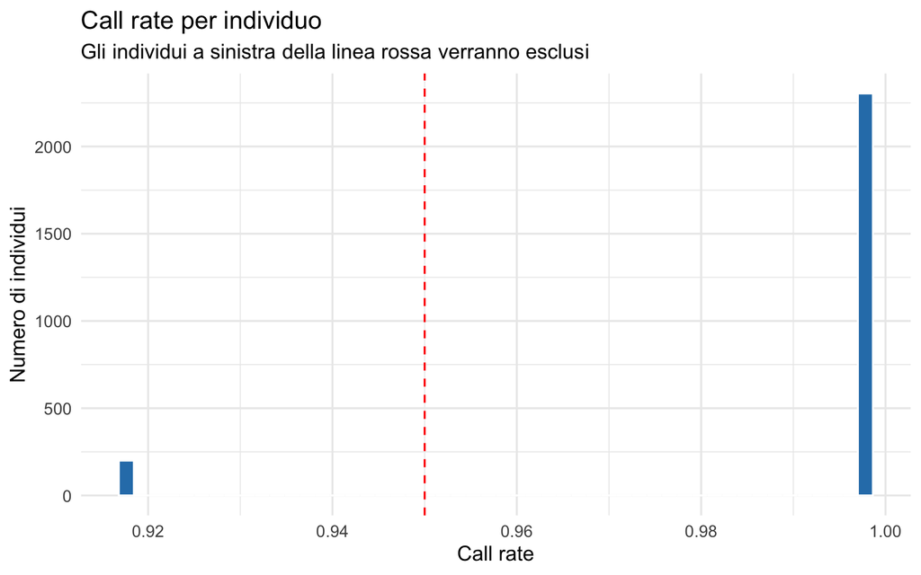

Call rate per individuo — la linea rossa è la soglia 95%

```r
ind_callrate_threshold <- 0.95

ggplot(data.frame(cr = rs$Call.rate), aes(x = cr)) +
  geom_histogram(bins = 50, fill = "#2c7fb8", color = "white") +
  geom_vline(xintercept = ind_callrate_threshold, linetype = "dashed", color = "red") +
  labs(x = "Call rate", y = "Numero di individui",
       title = "Call rate per individuo",
       subtitle = "Gli individui a sinistra della linea rossa verranno esclusi")
```

```r
fail_callrate <- rs$Call.rate < ind_callrate_threshold
n_fail_cr <- sum(fail_callrate & keep_ind)

cat(sprintf("Individui con call rate < %.0f%%: %d\n",
            ind_callrate_threshold * 100, n_fail_cr))
```

```
## Individui con call rate < 95%: 200
```

```r
keep_ind <- keep_ind & !fail_callrate
log_step("Sample call rate < 0.95", "individui", n_fail_cr, sum(keep_ind))
```

## 1.3 Filtro per eterozigosi anomala

L’eterozigosi di un individuo dovrebbe essere vicina alla media della popolazione. Valori **troppo alti** suggeriscono contaminazione del campione (DNA di due persone mescolato); valori **troppo bassi** suggeriscono consanguineità o problemi tecnici. Escludiamo chi è oltre **±3 deviazioni standard** dalla media.

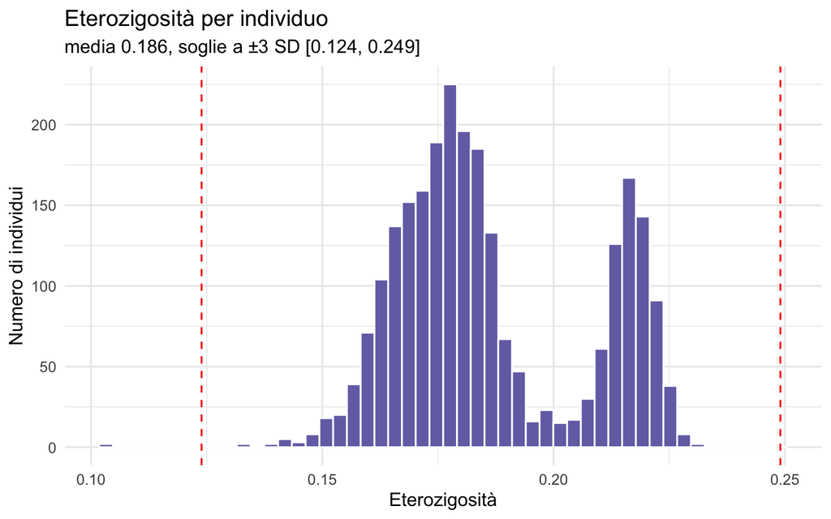

Eterozigosi per individuo — le linee rosse sono ±3 SD

```r
het_mean <- mean(rs$Heterozygosity, na.rm = TRUE)
het_sd   <- sd(rs$Heterozygosity, na.rm = TRUE)
het_lo   <- het_mean - 3 * het_sd
het_hi   <- het_mean + 3 * het_sd

ggplot(data.frame(het = rs$Heterozygosity), aes(x = het)) +
  geom_histogram(bins = 50, fill = "#7570b3", color = "white") +
  geom_vline(xintercept = c(het_lo, het_hi), linetype = "dashed", color = "red") +
  labs(x = "Eterozigosità", y = "Numero di individui",
       title = "Eterozigosità per individuo",
       subtitle = sprintf("media %.3f, soglie a ±3 SD [%.3f, %.3f]",
                          het_mean, het_lo, het_hi))
```

```r
fail_het <- rs$Heterozygosity < het_lo | rs$Heterozygosity > het_hi
n_fail_het <- sum(fail_het & keep_ind)

cat(sprintf("Individui con eterozigosità anomala (±3 SD): %d\n", n_fail_het))
```

```
## Individui con eterozigosità anomala (±3 SD): 3
```

```r
keep_ind <- keep_ind & !fail_het
log_step("Eterozigosità outlier (±3 SD)", "individui", n_fail_het, sum(keep_ind))
```

> **Nota didattica**: spesso call rate ed eterozigosi si guardano insieme in uno scatter plot (heterozygosity vs missingness). Un individuo con alta missingness *e* eterozigosi anomala è quasi certamente un campione da scartare.

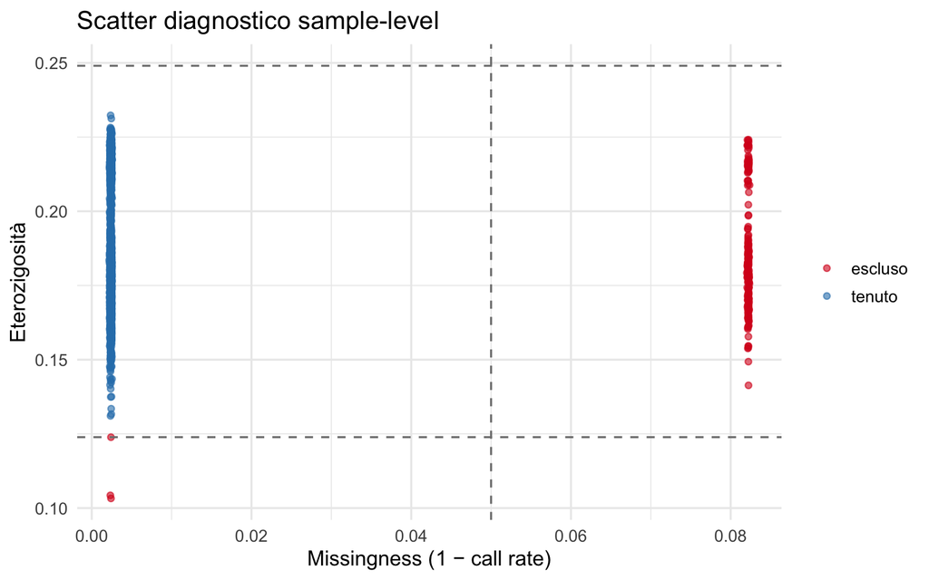

Eterozigosità vs missingness — lo scatter diagnostico classico

```r
diag_df <- data.frame(
  miss = 1 - rs$Call.rate,
  het  = rs$Heterozygosity,
  stato = ifelse(fail_callrate | fail_het, "escluso", "tenuto")
)
ggplot(diag_df, aes(x = miss, y = het, color = stato)) +
  geom_point(alpha = 0.6, size = 1.5) +
  scale_color_manual(values = c("escluso" = "#d7191c", "tenuto" = "#2c7fb8")) +
  geom_vline(xintercept = 1 - ind_callrate_threshold, linetype = "dashed", color = "grey50") +
  geom_hline(yintercept = c(het_lo, het_hi), linetype = "dashed", color = "grey50") +
  labs(x = "Missingness (1 − call rate)", y = "Eterozigosità",
       title = "Scatter diagnostico sample-level",
       color = NULL)
```

# 2. QC variant-level (sugli SNP)

Ora i filtri sugli **SNP**. Importante: li calcoliamo **solo sugli individui che abbiamo tenuto** finora, perché le statistiche degli SNP cambiano quando rimuoviamo individui problematici.

## 2.1 Statistiche per SNP (sui soli individui tenuti)

```r
# col.summary sugli individui sopravvissuti al QC sample-level
cs <- col.summary(snp_mat[keep_ind, ])
head(cs)
```

|  | Calls | Call.rate | Certain.calls | RAF | MAF | P.AA | P.AB | P.BB | z.HWE |
| --- | --- | --- | --- | --- | --- | --- | --- | --- | --- |
| rs112920234 | 2301 | 1 | 1 | 0.9815298 | 0.01847023 | 0.0008691873 | 0.03520209 | 0.9639287 | -1.3971647 |
| rs569167217 | 2301 | 1 | 1 | 0.9871795 | 0.01282051 | 0.0004345937 | 0.02477184 | 0.9747936 | -1.0242060 |
| rs61838556 | 2301 | 1 | 1 | 0.5162973 | 0.48370274 | 0.4215558453 | 0.12429379 | 0.4541504 | -36.0316253 |
| rs548639866 | 2301 | 1 | 1 | 0.9869622 | 0.01303781 | 0.0004345937 | 0.02520643 | 0.9743590 | -0.9864113 |
| rs147855157 | 2301 | 1 | 1 | 0.4089526 | 0.40895263 | 0.3437635811 | 0.49456758 | 0.1616688 | 1.1060742 |
| rs536439816 | 2301 | 1 | 1 | 0.9893525 | 0.01064754 | 0.0000000000 | 0.02129509 | 0.9787049 | 0.5162460 |

Colonne che useremo: `Call.rate` (call rate per SNP), `MAF`, `z.HWE` (z-score di Hardy–Weinberg).

## 2.2 Filtro per call rate (SNP)

Stesso principio degli individui: uno SNP genotipizzato male in troppi soggetti va tolto. Soglia: **call rate ≥ 95%**.

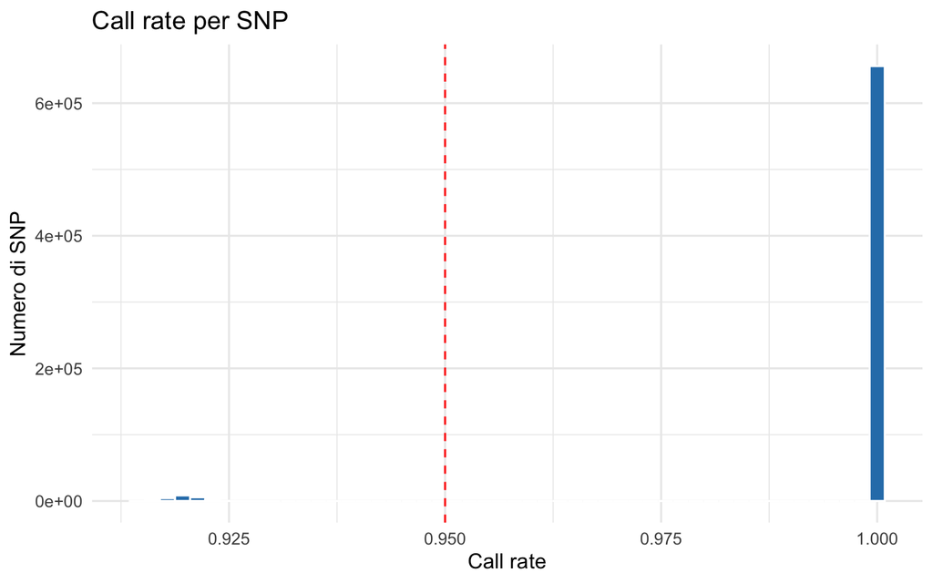

Call rate per SNP

```r
snp_callrate_threshold <- 0.95

ggplot(data.frame(cr = cs$Call.rate), aes(x = cr)) +
  geom_histogram(bins = 50, fill = "#2c7fb8", color = "white") +
  geom_vline(xintercept = snp_callrate_threshold, linetype = "dashed", color = "red") +
  labs(x = "Call rate", y = "Numero di SNP",
       title = "Call rate per SNP")
```

```r
fail_snp_cr <- cs$Call.rate < snp_callrate_threshold
fail_snp_cr[is.na(fail_snp_cr)] <- TRUE
n_fail_snp_cr <- sum(fail_snp_cr & keep_snp)

cat(sprintf("SNP con call rate < %.0f%%: %s\n",
            snp_callrate_threshold * 100, format(n_fail_snp_cr, big.mark = ",")))
```

```
## SNP con call rate < 95%: 20,284
```

```r
keep_snp <- keep_snp & !fail_snp_cr
log_step("SNP call rate < 0.95", "SNP", n_fail_snp_cr, sum(keep_snp))
```

## 2.3 Filtro per MAF

Le varianti troppo rare hanno potenza statistica insufficiente per il test single-SNP. Soglia: **MAF ≥ 0.01**.

```r
maf_threshold <- 0.01

fail_maf <- cs$MAF < maf_threshold
fail_maf[is.na(fail_maf)] <- TRUE
# applichiamo solo agli SNP ancora in gioco
n_fail_maf <- sum(fail_maf & keep_snp)

cat(sprintf("SNP con MAF < %.2f: %s\n",
            maf_threshold, format(n_fail_maf, big.mark = ",")))
```

```
## SNP con MAF < 0.01: 2,699
```

```r
keep_snp <- keep_snp & !fail_maf
log_step("SNP MAF < 0.01", "SNP", n_fail_maf, sum(keep_snp))
```

## 2.4 Filtro per Hardy–Weinberg

Ricordate dalla Lezione 1: un SNP che viola HWE in modo grossolano è probabilmente un errore di genotipizzazione. Soglia standard GWAS: **p_HWE ≥ 1e-6**.

> ⚠️ **Attenzione cruciale**: nei dataset caso-controllo, il filtro HWE si applica **solo nei controlli**. Perché? Una vera variante di rischio *può* violare HWE legittimamente nei casi (l’arricchimento di un genotipo nei malati distorce le frequenze). Filtrare nei casi rimuoverebbe proprio gli SNP che vogliamo trovare.

```r
hwe_threshold <- 1e-6

# HWE calcolato SOLO NEI CONTROLLI (pheno == 1), tra gli individui tenuti
controls_idx <- which(fam$pheno == 1 & keep_ind)
cs_controls <- col.summary(snp_mat[controls_idx, ])

# z.HWE → p-value
hwe_p_controls <- pchisq(cs_controls$z.HWE^2, df = 1, lower.tail = FALSE)

fail_hwe <- hwe_p_controls < hwe_threshold
fail_hwe[is.na(fail_hwe)] <- FALSE   # NA = monomorfici nei controlli, non li tocchiamo qui
n_fail_hwe <- sum(fail_hwe & keep_snp)

cat(sprintf("SNP con p_HWE < 1e-6 (nei controlli): %s\n",
            format(n_fail_hwe, big.mark = ",")))
```

```
## SNP con p_HWE < 1e-6 (nei controlli): 162,447
```

```r
keep_snp <- keep_snp & !fail_hwe
log_step("SNP HWE p<1e-6 (controlli)", "SNP", n_fail_hwe, sum(keep_snp))
```

## 2.5 Differential missingness

Filtro più sottile ma importante: uno SNP che è mancante **più spesso nei casi che nei controlli** (o viceversa) genera associazioni false. La missingness differenziale è una fonte classica di falsi positivi.

```r
# Call rate dello SNP separatamente in casi e controlli (tra gli individui tenuti)
cases_idx <- which(fam$pheno == 2 & keep_ind)
ctrls_idx <- which(fam$pheno == 1 & keep_ind)

cs_cases <- col.summary(snp_mat[cases_idx, ])
cs_ctrls <- col.summary(snp_mat[ctrls_idx, ])

# Test: differenza di missingness tra casi e controlli
miss_cases <- 1 - cs_cases$Call.rate
miss_ctrls <- 1 - cs_ctrls$Call.rate
miss_diff  <- abs(miss_cases - miss_ctrls)

# Soglia pragmatica: differenza di missingness > 2%
diffmiss_threshold <- 0.02
fail_diffmiss <- miss_diff > diffmiss_threshold
fail_diffmiss[is.na(fail_diffmiss)] <- FALSE
n_fail_diffmiss <- sum(fail_diffmiss & keep_snp)

cat(sprintf("SNP con differential missingness > %.0f%%: %s\n",
            diffmiss_threshold * 100, format(n_fail_diffmiss, big.mark = ",")))
```

```
## SNP con differential missingness > 2%: 0
```

```r
keep_snp <- keep_snp & !fail_diffmiss
log_step("SNP differential missingness", "SNP", n_fail_diffmiss, sum(keep_snp))
```

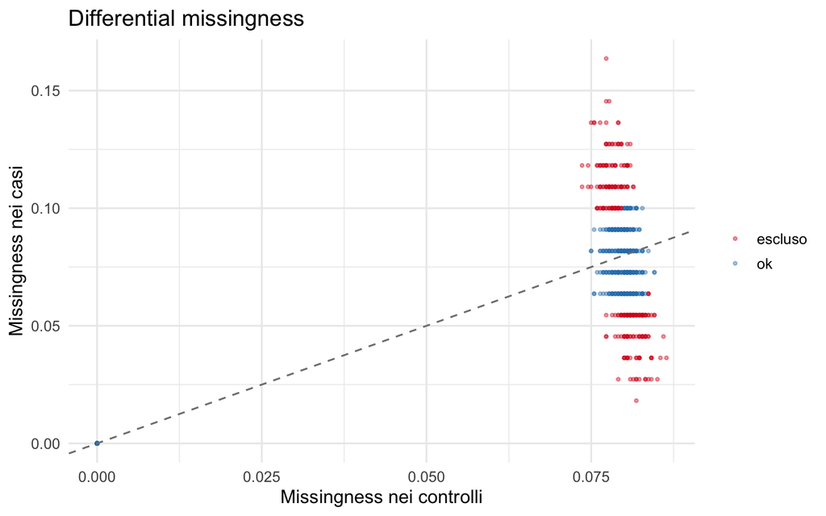

Missingness nei casi vs nei controlli — punti rossi = differential missingness

```r
dm_df <- data.frame(
  miss_ctrls = miss_ctrls,
  miss_cases = miss_cases,
  flag = ifelse(fail_diffmiss, "escluso", "ok")
)
# campioniamo per non appesantire il plot
set.seed(1); dm_df <- dm_df[sample(nrow(dm_df), min(20000, nrow(dm_df))), ]

ggplot(dm_df, aes(x = miss_ctrls, y = miss_cases, color = flag)) +
  geom_point(alpha = 0.4, size = 0.8) +
  geom_abline(slope = 1, intercept = 0, color = "grey50", linetype = "dashed") +
  scale_color_manual(values = c("escluso" = "#d7191c", "ok" = "#2c7fb8")) +
  labs(x = "Missingness nei controlli", y = "Missingness nei casi",
       title = "Differential missingness", color = NULL)
```

# 3. La tabella before/after

Questo è il riassunto che va in ogni paper GWAS: quanti SNP e quanti individui c’erano all’inizio, quanti ne abbiamo tolti a ogni passo, quanti ne restano.

```r
exclusion_log
```

| passo | tipo | n_rimossi | n_rimasti |
| --- | --- | --- | --- |
| Sample call rate < 0.95 | individui | 200 | 2304 |
| Eterozigosità outlier (±3 SD) | individui | 3 | 2301 |
| SNP call rate < 0.95 | SNP | 20284 | 655864 |
| SNP MAF < 0.01 | SNP | 2699 | 653165 |
| SNP HWE p<1e-6 (controlli) | SNP | 162447 | 490718 |
| SNP differential missingness | SNP | 0 | 490718 |

```r
n_snp_end <- sum(keep_snp)
n_ind_end <- sum(keep_ind)

before_after <- data.frame(
  Metrica = c("SNP", "Individui", "Casi", "Controlli"),
  Prima = c(
    format(n_snp_start, big.mark = ","),
    n_ind_start,
    sum(fam$pheno == 2, na.rm = TRUE),
    sum(fam$pheno == 1, na.rm = TRUE)
  ),
  Dopo = c(
    format(n_snp_end, big.mark = ","),
    n_ind_end,
    sum(fam$pheno == 2 & keep_ind, na.rm = TRUE),
    sum(fam$pheno == 1 & keep_ind, na.rm = TRUE)
  ),
  Rimossi = c(
    format(n_snp_start - n_snp_end, big.mark = ","),
    n_ind_start - n_ind_end,
    sum(fam$pheno == 2, na.rm = TRUE) - sum(fam$pheno == 2 & keep_ind, na.rm = TRUE),
    sum(fam$pheno == 1, na.rm = TRUE) - sum(fam$pheno == 1 & keep_ind, na.rm = TRUE)
  )
)
before_after
```

| Metrica | Prima | Dopo | Rimossi |
| --- | --- | --- | --- |
| SNP | 676,148 | 490,718 | 185,430 |
| Individui | 2504 | 2301 | 203 |
| Casi | 250 | 110 | 140 |
| Controlli | 2250 | 2187 | 63 |

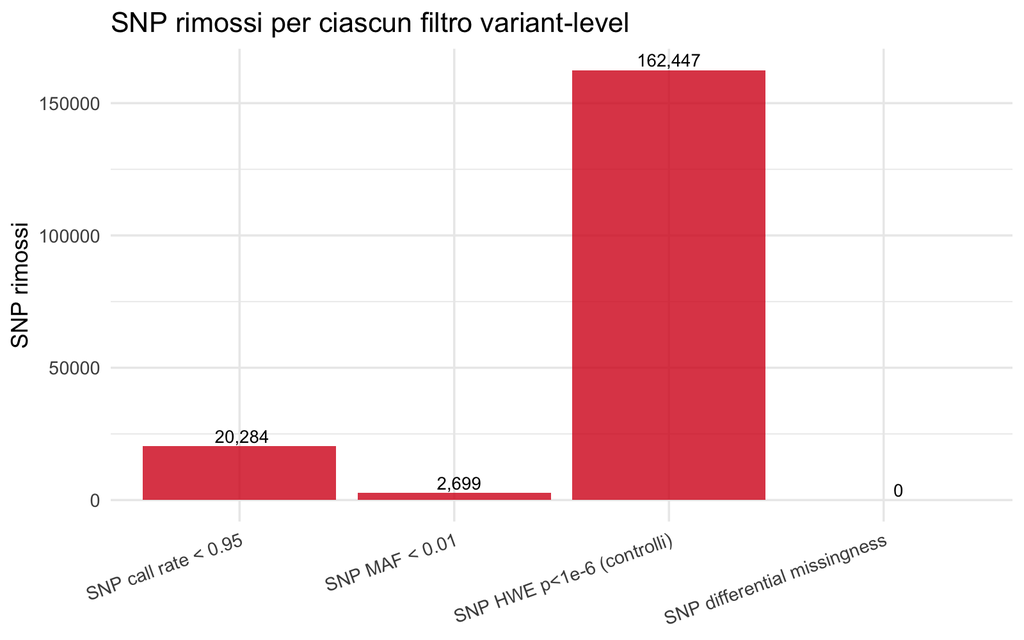

SNP rimossi a ogni passo del QC variant-level

```r
snp_steps <- exclusion_log[exclusion_log$tipo == "SNP", ]
snp_steps$passo <- factor(snp_steps$passo, levels = snp_steps$passo)

ggplot(snp_steps, aes(x = passo, y = n_rimossi)) +
  geom_col(fill = "#d7191c", alpha = 0.8) +
  geom_text(aes(label = format(n_rimossi, big.mark = ",")), vjust = -0.3, size = 3.5) +
  labs(x = NULL, y = "SNP rimossi",
       title = "SNP rimossi per ciascun filtro variant-level") +
  theme(axis.text.x = element_text(angle = 20, hjust = 1))
```

# 4. Applicare il QC: il dataset filtrato

Adesso costruiamo il dataset pulito applicando le due maschere `keep_snp` e `keep_ind`.

```r
snp_mat_qc <- snp_mat[keep_ind, keep_snp]
fam_qc     <- fam[keep_ind, ]

cat(sprintf("Dataset dopo QC:\n  %s SNP × %d individui\n",
            format(ncol(snp_mat_qc), big.mark = ","),
            nrow(snp_mat_qc)))
```

```
## Dataset dopo QC:
##   490,718 SNP × 2301 individui
```

> A questo punto, in un workflow reale, salveremmo il dataset pulito su disco (es. `write.plink(...)`) come `T2D_chr10_qc`. Per il lab lo teniamo in memoria e proseguiamo con PCA e GRM.

# 5. PCA — struttura di popolazione

Ora la parte di stratificazione. Calcoliamo le componenti principali sul dataset **dopo il QC**, per identificare la struttura di popolazione e gli outlier di ancestry.

## 5.1 LD pruning (prima della PCA)

> **Perché?** La PCA assume che le variabili (gli SNP) portino informazione indipendente. Gli SNP in forte LD sono ridondanti e possono distorcere le componenti (un blocco LD denso “tira” le PC verso di sé). Quindi prima della PCA si fa un **LD pruning**: si tiene un sottoinsieme di SNP approssimativamente indipendenti.

```r
# snpStats non ha un pruner integrato comodo; usiamo un pruning per finestre
# basato sulla correlazione. Per semplicità e velocità nel lab, prendiamo
# un sottocampione di SNP comuni e ben distanziati.

cs_qc <- col.summary(snp_mat_qc)
bim_qc <- bim[keep_snp, ]

# Teniamo SNP comuni (MAF >= 0.05) e con call rate alto
prune_candidates <- which(cs_qc$MAF >= 0.05 & cs_qc$Call.rate >= 0.99)

# Pruning "fisico" semplice: 1 SNP ogni ~25 kb (proxy del pruning per LD)
# (un vero LD pruning userebbe r²; qui usiamo la distanza per semplicità didattica)
pos_candidates <- bim_qc$pos[prune_candidates]
ord <- order(pos_candidates)
prune_candidates <- prune_candidates[ord]
pos_sorted <- pos_candidates[ord]

keep_pruned <- logical(length(prune_candidates))
last_pos <- -Inf
for (i in seq_along(prune_candidates)) {
  if (pos_sorted[i] - last_pos >= 25000) {
    keep_pruned[i] <- TRUE
    last_pos <- pos_sorted[i]
  }
}
pruned_idx <- prune_candidates[keep_pruned]

cat(sprintf("SNP dopo pruning per la PCA: %s (da %s comuni)\n",
            format(length(pruned_idx), big.mark = ","),
            format(length(prune_candidates), big.mark = ",")))
```

```
## SNP dopo pruning per la PCA: 5,015 (da 255,927 comuni)
```

> **Nota**: qui usiamo un pruning “fisico” (1 SNP ogni 25 kb) per semplicità e velocità. In un’analisi reale si usa il pruning per **r²** (es. PLINK `--indep-pairwise 50 5 0.2`), che è più rigoroso. Il concetto è lo stesso: ridurre la ridondanza da LD.

## 5.2 Calcolo delle componenti principali

Usiamo lo stesso approccio della preview della Lezione 1: la matrice `xxt` (X·Xᵀ) e la sua decomposizione in autovettori.

```r
snp_pca <- snp_mat_qc[, pruned_idx]

# xxt calcola X X^T (matrice ind × ind), gestendo i missing come media
xxt <- snpStats::xxt(snp_pca, correct.for.missing = TRUE)

# Eigendecomposition
eig <- eigen(xxt, symmetric = TRUE)

# Le prime PC sono gli autovettori principali
n_pc <- 10
pcs <- eig$vectors[, 1:n_pc]
colnames(pcs) <- paste0("PC", 1:n_pc)

# Varianza spiegata da ciascuna PC
var_explained <- eig$values[1:n_pc] / sum(eig$values)

pc_df <- data.frame(pcs, super_pop = fam_qc$super_pop,
                    pheno = factor(fam_qc$pheno))
```

## 5.3 Scree plot — quante PC tenere?

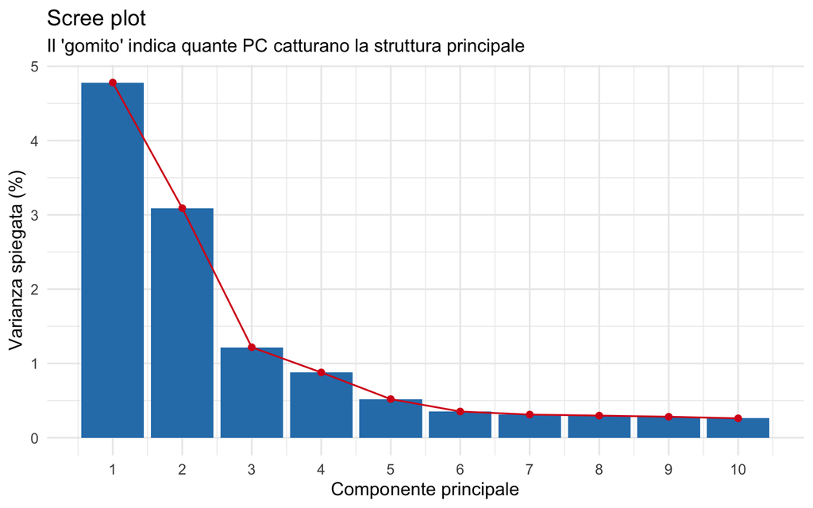

Scree plot — varianza spiegata dalle prime 10 PC

```r
scree_df <- data.frame(PC = 1:n_pc, var = var_explained * 100)
ggplot(scree_df, aes(x = PC, y = var)) +
  geom_col(fill = "#2c7fb8") +
  geom_line(color = "#d7191c") + geom_point(color = "#d7191c") +
  scale_x_continuous(breaks = 1:n_pc) +
  labs(x = "Componente principale", y = "Varianza spiegata (%)",
       title = "Scree plot",
       subtitle = "Il 'gomito' indica quante PC catturano la struttura principale")
```

📌 **Lettura**: le prime PC (di solito 2-4) catturano la struttura di ancestry; dopo il “gomito” le PC catturano rumore. Come covariate nel GWAS (Lezione 4) si usano in genere le prime 10 per sicurezza.

## 5.4 PC1 vs PC2 colorate per super-popolazione

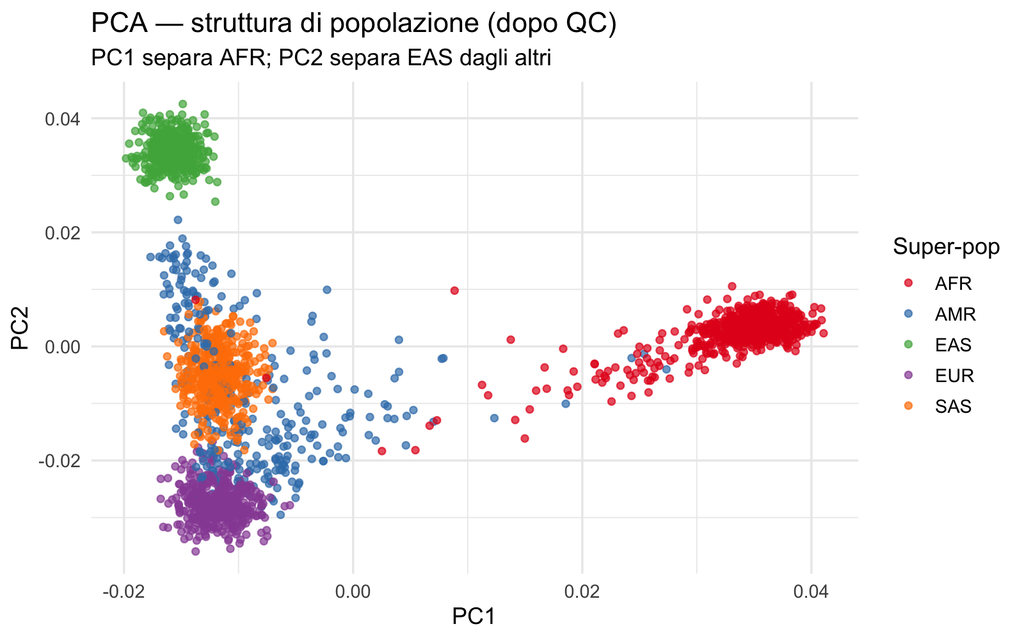

PC1 vs PC2 colorate per super-popolazione

```r
ggplot(pc_df, aes(x = PC1, y = PC2, color = super_pop)) +
  geom_point(alpha = 0.7, size = 1.5) +
  scale_color_brewer(palette = "Set1", name = "Super-pop") +
  labs(title = "PCA — struttura di popolazione (dopo QC)",
       subtitle = "PC1 separa AFR; PC2 separa EAS dagli altri")
```

# 6. Identificazione e rimozione degli outlier di ancestry

Nel dataset noisy abbiamo iniettato apposta degli **outlier di ancestry**: individui di popolazione diversa dalla maggioritaria. Sulla PCA si vedono come punti lontani dal cluster principale. Li identifichiamo e li rimuoviamo, perché in un GWAS la stratificazione residua genera falsi positivi.

## 6.1 Definire la popolazione “core”

> **Scelta analitica**: in un GWAS reale si decide a quale popolazione restringere l’analisi (es. “teniamo solo gli europei”). Qui, a scopo didattico, definiamo come “core” la popolazione maggioritaria e trattiamo le altre come outlier da rimuovere — è il caso più semplice di controllo della stratificazione.

```r
core_pop <- names(sort(table(fam_qc$super_pop), decreasing = TRUE))[1]
cat(sprintf("Popolazione core (maggioritaria): %s\n", core_pop))
```

```
## Popolazione core (maggioritaria): AFR
```

## 6.2 Identificare gli outlier sulle PC

Definiamo outlier chi è oltre **±6 SD** dalla media delle prime due PC (criterio standard). In un dataset con popolazione core dominante, questo cattura gli individui di ancestry diversa.

```r
sd_threshold <- 6

pc1_mean <- mean(pcs[, 1]); pc1_sd <- sd(pcs[, 1])
pc2_mean <- mean(pcs[, 2]); pc2_sd <- sd(pcs[, 2])

outlier_pca <- abs(pcs[, 1] - pc1_mean) > sd_threshold * pc1_sd |
               abs(pcs[, 2] - pc2_mean) > sd_threshold * pc2_sd

# Approccio alternativo (più robusto qui, dato che le pop sono molto separate):
# marchiamo come outlier chi NON appartiene alla popolazione core.
outlier_ancestry <- fam_qc$super_pop != core_pop

cat(sprintf("Outlier per criterio ±6 SD sulle PC: %d\n", sum(outlier_pca)))
```

```
## Outlier per criterio ±6 SD sulle PC: 0
```

```r
cat(sprintf("Individui non-core (ancestry diversa da %s): %d\n",
            core_pop, sum(outlier_ancestry, na.rm = TRUE)))
```

```
## Individui non-core (ancestry diversa da AFR): 1682
```

> **Nota didattica**: i due criteri (±6 SD sulle PC vs appartenenza alla popolazione core) danno risultati diversi. Il criterio SD è “data-driven” ma in un dataset così strutturato può non separare bene; il criterio per ancestry nota è più netto ma richiede l’etichetta di popolazione. Nella pratica reale, dove non si hanno etichette perfette, si usa il criterio sulle PC iterativamente. Qui, avendo le etichette 1000G, usiamo l’appartenenza alla core per pulizia didattica.

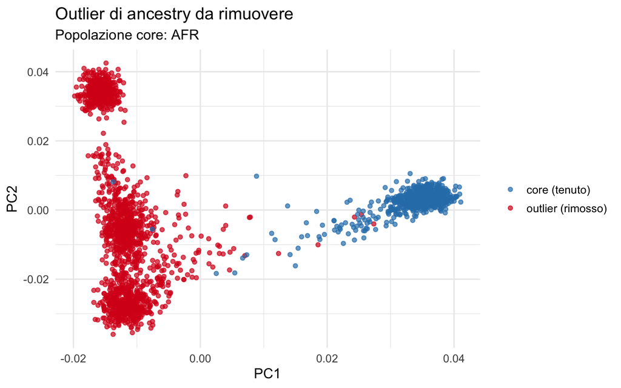

Outlier di ancestry evidenziati sulla PCA

```r
pc_df$outlier <- outlier_ancestry
ggplot(pc_df, aes(x = PC1, y = PC2, color = outlier)) +
  geom_point(alpha = 0.7, size = 1.5) +
  scale_color_manual(values = c("FALSE" = "#2c7fb8", "TRUE" = "#d7191c"),
                     labels = c("FALSE" = "core (tenuto)", "TRUE" = "outlier (rimosso)"),
                     name = NULL) +
  labs(title = "Outlier di ancestry da rimuovere",
       subtitle = sprintf("Popolazione core: %s", core_pop))
```

## 6.3 Rimuovere gli outlier

```r
keep_after_pca <- !outlier_ancestry
keep_after_pca[is.na(keep_after_pca)] <- FALSE

n_outlier <- sum(!keep_after_pca)
cat(sprintf("Outlier di ancestry rimossi: %d\n", n_outlier))
```

```
## Outlier di ancestry rimossi: 1682
```

```r
snp_mat_final <- snp_mat_qc[keep_after_pca, ]
fam_final     <- fam_qc[keep_after_pca, ]

log_step("Outlier di ancestry (PCA)", "individui", n_outlier, nrow(snp_mat_final))

cat(sprintf("\nDataset finale (post-QC + post-ancestry):\n  %s SNP × %d individui\n",
            format(ncol(snp_mat_final), big.mark = ","),
            nrow(snp_mat_final)))
```

```
##
## Dataset finale (post-QC + post-ancestry):
##   490,718 SNP × 619 individui
```

```r
cat(sprintf("  Casi: %d | Controlli: %d\n",
            sum(fam_final$pheno == 2, na.rm = TRUE),
            sum(fam_final$pheno == 1, na.rm = TRUE)))
```

```
##   Casi: 22 | Controlli: 597
```

## 6.4 PCA ricalcolata sul dataset pulito

Dopo aver rimosso gli outlier, ricalcoliamo la PCA: ora le PC catturano la struttura *fine* dentro la popolazione core, non più la macro-separazione tra popolazioni.

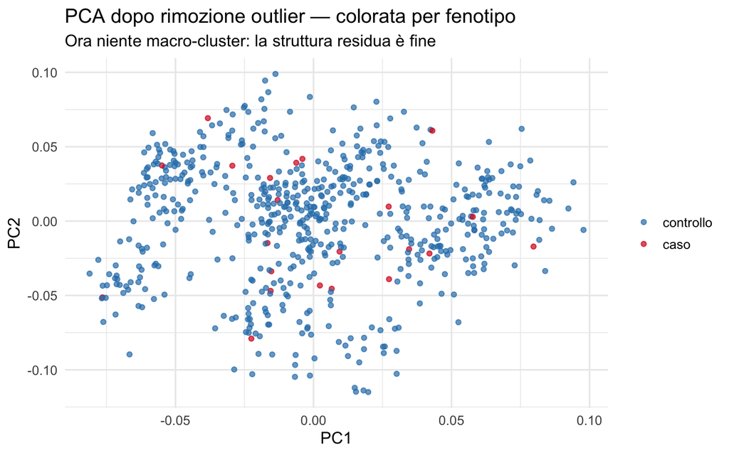

PCA dopo la rimozione degli outlier di ancestry

```r
# Pruning sul dataset finale
cs_final <- col.summary(snp_mat_final)
common_final <- which(cs_final$MAF >= 0.05 & cs_final$Call.rate >= 0.99)
set.seed(20260101)
sub_final <- sample(common_final, min(20000, length(common_final)))

xxt_final <- snpStats::xxt(snp_mat_final[, sub_final], correct.for.missing = TRUE)
eig_final <- eigen(xxt_final, symmetric = TRUE)
pcs_final <- eig_final$vectors[, 1:n_pc]
colnames(pcs_final) <- paste0("PC", 1:n_pc)

pc_final_df <- data.frame(pcs_final,
                          super_pop = fam_final$super_pop,
                          pheno = factor(fam_final$pheno))

ggplot(pc_final_df, aes(x = PC1, y = PC2, color = pheno)) +
  geom_point(alpha = 0.7, size = 1.5) +
  scale_color_manual(values = c("1" = "#2c7fb8", "2" = "#d7191c"),
                     labels = c("1" = "controllo", "2" = "caso"), name = NULL) +
  labs(title = "PCA dopo rimozione outlier — colorata per fenotipo",
       subtitle = "Ora niente macro-cluster: la struttura residua è fine")
```

📌 **Cosa osservare**: dopo la rimozione, non ci sono più cluster netti per popolazione. Se i casi e i controlli (colori) si sovrappongono bene, è un buon segno: vuol dire che non c’è confondimento residuo grossolano tra fenotipo e struttura genetica. Queste PC finali sono quelle che useremo come covariate nel GWAS della Lezione 4.

# 7. GRM — Genetic Relationship Matrix

La GRM quantifica la **parentela genetica** tra ogni coppia di individui. Serve a due cose: (1) identificare individui imparentati o duplicati (da rimuovere o modellare), (2) come input per i modelli misti (mixed models) che vedremo più avanti.

## 7.1 Costruzione della GRM

La GRM è essenzialmente la matrice X·Xᵀ standardizzata — la stessa `xxt` che abbiamo usato per la PCA, ma normalizzata in modo da rappresentare la correlazione genetica tra individui.

```r
# Usiamo gli SNP comuni del dataset finale, standardizzati
# La GRM standard (VanRaden / GCTA) usa: G = Z Z' / m, con Z genotipi
# centrati e scalati per la frequenza allelica.

# Estraiamo i genotipi come matrice numerica (ind × snp)
G_final <- as(snp_mat_final[, sub_final], "numeric")  # 0/1/2, NA possibili

# Imputazione semplice dei missing con la media di colonna
col_means <- colMeans(G_final, na.rm = TRUE)
for (j in seq_len(ncol(G_final))) {
  na_j <- is.na(G_final[, j])
  if (any(na_j)) G_final[na_j, j] <- col_means[j]
}

# Standardizzazione per SNP: (g - 2p) / sqrt(2p(1-p))
p_hat <- col_means / 2
denom <- sqrt(2 * p_hat * (1 - p_hat))
denom[denom == 0] <- 1  # evita divisione per zero su SNP monomorfici
Z <- sweep(G_final, 2, 2 * p_hat, "-")
Z <- sweep(Z, 2, denom, "/")

# GRM = Z Z' / m
m <- ncol(Z)
GRM <- (Z %*% t(Z)) / m

cat(sprintf("GRM: matrice %d × %d (individui)\n", nrow(GRM), ncol(GRM)))
```

```
## GRM: matrice 619 × 619 (individui)
```

## 7.2 Interpretazione della diagonale e fuori-diagonale

```r
# Diagonale: ~1 + inbreeding. Valori molto sopra 1 = possibile inbreeding/problema.
diag_grm <- diag(GRM)

# Fuori-diagonale: parentela tra coppie. ~0 = non imparentati.
# ~0.5 = parenti di primo grado (genitore-figlio, fratelli); ~1 = duplicati/gemelli.
offdiag <- GRM[upper.tri(GRM)]

cat("Diagonale della GRM (self-relatedness):\n")
```

```
## Diagonale della GRM (self-relatedness):
```

```r
print(summary(diag_grm))
```

```
##    Min. 1st Qu.  Median    Mean 3rd Qu.    Max.
##  0.8415  0.9721  0.9969  0.9954  1.0194  1.1215
```

```r
cat("\nFuori-diagonale (parentela tra coppie):\n")
```

```
##
## Fuori-diagonale (parentela tra coppie):
```

```r
print(summary(offdiag))
```

```
##      Min.   1st Qu.    Median      Mean   3rd Qu.      Max.
## -0.075228 -0.013678 -0.002316 -0.001611  0.009642  0.610302
```

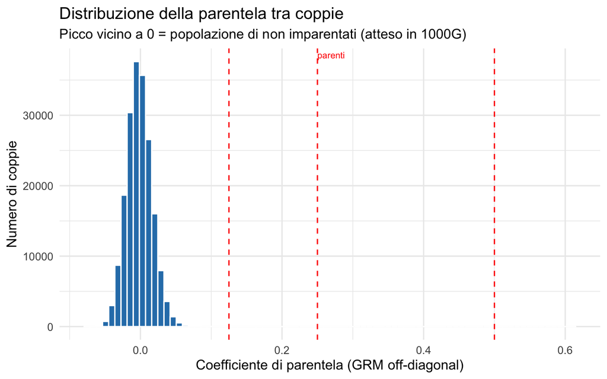

Distribuzione della parentela fuori-diagonale

```r
ggplot(data.frame(rel = offdiag), aes(x = rel)) +
  geom_histogram(bins = 80, fill = "#2c7fb8", color = "white") +
  geom_vline(xintercept = c(0.125, 0.25, 0.5), linetype = "dashed", color = "red") +
  annotate("text", x = 0.25, y = Inf, label = "parenti", color = "red",
           hjust = 0, vjust = 1.5, size = 3) +
  labs(x = "Coefficiente di parentela (GRM off-diagonal)", y = "Numero di coppie",
       title = "Distribuzione della parentela tra coppie",
       subtitle = "Picco vicino a 0 = popolazione di non imparentati (atteso in 1000G)")
```

📌 **Lettura**: in 1000G gli individui sono in larga parte non imparentati, quindi la fuori-diagonale è concentrata vicino a zero. Eventuali coppie con parentela > 0.125 (parenti di terzo grado o più stretti) andrebbero gestite: in un GWAS standard se ne rimuove uno della coppia; in un mixed model si modella la GRM direttamente.

## 7.3 Heatmap della GRM (campione)

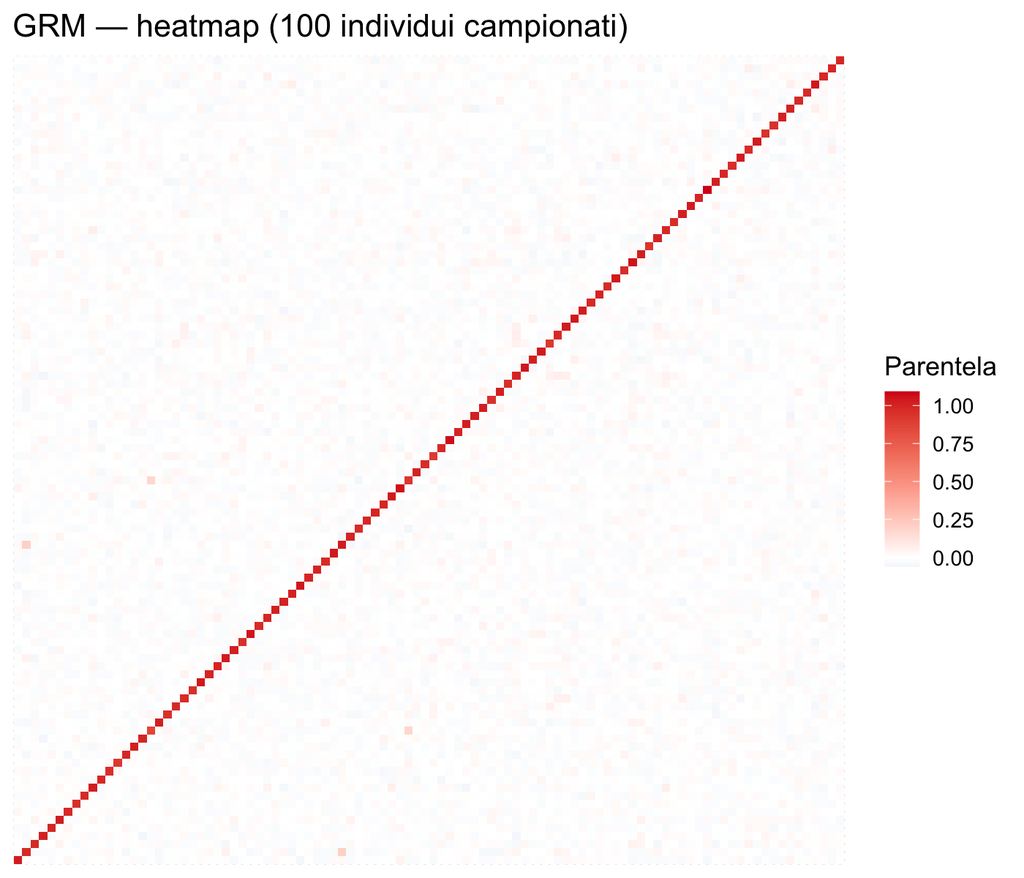

Heatmap della GRM su un campione di 100 individui

```r
set.seed(1)
samp <- sample(nrow(GRM), min(100, nrow(GRM)))
grm_sub <- GRM[samp, samp]

grm_long <- as.data.frame(as.table(grm_sub))
colnames(grm_long) <- c("ind1", "ind2", "rel")

ggplot(grm_long, aes(x = ind1, y = ind2, fill = rel)) +
  geom_tile() +
  scale_fill_gradient2(low = "#2c7fb8", mid = "white", high = "#d7191c",
                       midpoint = 0, name = "Parentela") +
  labs(title = "GRM — heatmap (100 individui campionati)",
       x = NULL, y = NULL) +
  theme(axis.text = element_blank(), axis.ticks = element_blank())
```

📌 **Lettura**: la diagonale (in rosso) è la self-relatedness ~1. Il resto della matrice è prevalentemente chiaro (parentela ~0), coerente con una popolazione di non imparentati. Macchie rosse fuori diagonale indicherebbero coppie di parenti.

# 8. Riepilogo finale

```r
cat("=== RIEPILOGO LAB 2 — QC + PCA + GRM ===\n\n")
```

```
## === RIEPILOGO LAB 2 — QC + PCA + GRM ===
```

```r
cat(sprintf("Dataset di partenza:  %s SNP × %d individui\n",
            format(n_snp_start, big.mark = ","), n_ind_start))
```

```
## Dataset di partenza:  676,148 SNP × 2504 individui
```

```r
cat(sprintf("Dopo QC variant+sample: %s SNP × %d individui\n",
            format(sum(keep_snp), big.mark = ","), sum(keep_ind)))
```

```
## Dopo QC variant+sample: 490,718 SNP × 2301 individui
```

```r
cat(sprintf("Dopo rimozione outlier: %s SNP × %d individui\n\n",
            format(ncol(snp_mat_final), big.mark = ","), nrow(snp_mat_final)))
```

```
## Dopo rimozione outlier: 490,718 SNP × 619 individui
```

```r
cat("Log completo delle esclusioni:\n")
```

```
## Log completo delle esclusioni:
```

```r
print(exclusion_log)
```

```
##                           passo      tipo n_rimossi n_rimasti
## 1       Sample call rate < 0.95 individui       200      2304
## 2 Eterozigosità outlier (±3 SD) individui         3      2301
## 3          SNP call rate < 0.95       SNP     20284    655864
## 4                SNP MAF < 0.01       SNP      2699    653165
## 5    SNP HWE p<1e-6 (controlli)       SNP    162447    490718
## 6  SNP differential missingness       SNP         0    490718
## 7     Outlier di ancestry (PCA) individui      1682       619
```

```r
cat(sprintf("\nProdotti del lab pronti per la Lezione 4 (GWAS):\n"))
```

```
##
## Prodotti del lab pronti per la Lezione 4 (GWAS):
```

```r
cat("  - snp_mat_final : dataset pulito\n")
```

```
##   - snp_mat_final : dataset pulito
```

```r
cat("  - pcs_final     : 10 PC da usare come covariate\n")
```

```
##   - pcs_final     : 10 PC da usare come covariate
```

```r
cat("  - GRM           : matrice di parentela per i mixed model\n")
```

```
##   - GRM           : matrice di parentela per i mixed model
```

# Cosa fare a casa

Rieseguite questo intero notebook sui vostri portatili, sul dataset `T2D_chr10_noisy`, e assicuratevi di capire **a ogni passo**:

1. **Quale statistica** stiamo calcolando (call rate, eterozigosi, MAF, HWE, missingness differenziale)
2. **Quale soglia** applichiamo e **perché** quel valore
3. **Cosa cambia** nella tabella before/after a ogni filtro
4. **Perché** la PCA va fatta dopo il QC e dopo il pruning
5. **Cosa rappresentano** le PC e la GRM, e a cosa serviranno nella Lezione 4

Nel vostro `.Rmd` di progetto, questa diventa la **Sezione 4 (Quality Control)** e la **Sezione 5 (PCA + GRM)**.

# Appendice — Comandi rapidi del QC

| Operazione | Funzione |
| --- | --- |
| Statistiche per individuo | `snpStats::row.summary(snp_mat)` |
| Statistiche per SNP | `snpStats::col.summary(snp_mat)` |
| Call rate individuo/SNP | colonna `Call.rate` |
| Eterozigosi | colonna `Heterozygosity` (row.summary) |
| MAF | colonna `MAF` (col.summary) |
| HWE z-score | colonna `z.HWE` (col.summary) → `pchisq(z^2, 1, lower=F)` |
| PCA (X Xᵀ) | `snpStats::xxt(snp_mat, correct.for.missing=TRUE)` poi `eigen()` |
| GRM standardizzata | `Z Z' / m` con `Z` = genotipi centrati/scalati per `2p(1-p)` |

**Soglie standard usate:**

| Filtro | Soglia |
| --- | --- |
| Call rate (individui) | ≥ 0.95 |
| Eterozigosi | entro ±3 SD |
| Call rate (SNP) | ≥ 0.95 |
| MAF | ≥ 0.01 |
| HWE (nei controlli) | p ≥ 1e-6 |
| Differential missingness | < 2% |
| Outlier ancestry | oltre core / ±6 SD su PC |